# Report

Hadi Sam Nariman

January 13, 2018

Uploading Needed Packages

```r
library(ggraph)
library(qgraph)
library(lavaan)
library(broom)
library(tidyr)
library(tidyverse)
library(ggplot2)
library(semPlot)
library(haven)
library(psych)
library(MVN)
library(stargazer)
library(car)
library(dplyr)
library(tibble)
```

Reading the Dataset

```r
coll_df = read.table("C:\\Users\\User\\Desktop\\To Mac\\Hadi-Final-Project\\Dataframe.dat", header=TRUE)
View (coll_df)
```

## Executive Summary

Using R statistical package (version 3.4.3), exploratory data analyses were performed and the current study’s hypotheses were tested by performing two stractural equation models. Exploratory data analyses contained checking for missing values, exploring the nature of the variables by summarizing the data in a table, checking for the outliers, checking for normality of the variable, and performing correlation analyses between dependent variables and between independent variables. By the first hypothesis we assumed that there will be a negative association between perception of the three forms of threat and support for the accommodation of migrants. The hypothesis was partially supported, and it was found that symbolic threat and realistic threat significantly and negatively predicted realistic, cultural, and political support for the accommodation of migrants, however, no such relationship was found between collective ownership threat and the dependent variables. The second hypothesis was that there will be a positive realtionship between exposure to threat and perception of negative feelings. Our Second hypothesis was again partially supported and it was found that symbolic threat significantly and positively predicted perception of negative feelings, while there was no such as association between the other two types of threat and perception of negative feelings.

## Description of the Dataset

435 participants (demographic information not available) were recruited a 7-point likert type questionnaire. The questionnaire measured support for the accommodation of migrants in the Netherlands, emotional reaction, and three forms of threat;collective ownership, symbolic, and realistic. Moreover, support for the accommodation of migrants measured three forms of support; realistic support, cultural support, and political support. The dataset was originally in an SPSS file which was later converted to a dat file, and finally read by R. The dataset was obtained from a professor in a Dutch university during an internship in the Ntherlands. Since, the dataset is supposed to be treated confidentially, the athour of the current paper cannot publish it and give further information about.

## Exploratory Data Analyses

Exploring Missing Variables in the Dataset

No missing values were found in the dataset

```r
sapply(coll_df,function(x) sum(is.na(x)))
```

```
##   q6_6   q6_9  q6_10  q16_1  q16_2  q16_3  q16_4  q16_5  q16_6  q16_7
##      0      0      0      0      0      0      0      0      0      0
##  q16_8  q16_9 q16_10 q16_11 q16_12  q18_1  q18_2  q18_3  q18_4  q18_5
##      0      0      0      0      0      0      0      0      0      0
##  q18_6
##      0
```

Exploring the Nature of the Variables

```r
summary(coll_df)
```

```
##       q6_6             q6_9            q6_10            q16_1
##  Min.   : 1.000   Min.   : 1.000   Min.   : 1.000   Min.   :1.00
##  1st Qu.: 4.000   1st Qu.: 3.000   1st Qu.: 4.000   1st Qu.:3.00
##  Median : 6.000   Median : 5.000   Median : 6.000   Median :5.00
##  Mean   : 5.464   Mean   : 4.738   Mean   : 5.949   Mean   :4.28
##  3rd Qu.: 7.000   3rd Qu.: 6.000   3rd Qu.: 8.000   3rd Qu.:6.00
##  Max.   :11.000   Max.   :11.000   Max.   :11.000   Max.   :7.00
##      q16_2           q16_3           q16_4          q16_5
##  Min.   :1.000   Min.   :1.000   Min.   :1.00   Min.   :1.000
##  1st Qu.:3.000   1st Qu.:3.000   1st Qu.:3.00   1st Qu.:3.000
##  Median :5.000   Median :5.000   Median :5.00   Median :4.000
##  Mean   :4.538   Mean   :4.407   Mean   :4.57   Mean   :4.239
##  3rd Qu.:6.000   3rd Qu.:6.000   3rd Qu.:6.00   3rd Qu.:5.000
##  Max.   :7.000   Max.   :7.000   Max.   :7.00   Max.   :7.000
##      q16_6           q16_7           q16_8           q16_9
##  Min.   :1.000   Min.   :1.000   Min.   :1.000   Min.   :1.000
##  1st Qu.:3.000   1st Qu.:3.000   1st Qu.:3.000   1st Qu.:3.000
##  Median :5.000   Median :4.000   Median :5.000   Median :4.000
##  Mean   :4.526   Mean   :4.326   Mean   :4.393   Mean   :4.225
##  3rd Qu.:6.000   3rd Qu.:6.000   3rd Qu.:6.000   3rd Qu.:6.000
##  Max.   :7.000   Max.   :7.000   Max.   :7.000   Max.   :7.000
##      q16_10          q16_11          q16_12         q18_1
##  Min.   :1.000   Min.   :1.000   Min.   :1.00   Min.   :1.000
##  1st Qu.:3.000   1st Qu.:3.000   1st Qu.:3.00   1st Qu.:3.000
##  Median :4.000   Median :4.000   Median :5.00   Median :4.000
##  Mean   :4.195   Mean   :4.149   Mean   :4.32   Mean   :3.784
##  3rd Qu.:6.000   3rd Qu.:6.000   3rd Qu.:6.00   3rd Qu.:5.000
##  Max.   :7.000   Max.   :7.000   Max.   :7.00   Max.   :7.000
##      q18_2           q18_3           q18_4           q18_5
##  Min.   :1.000   Min.   :1.000   Min.   :1.000   Min.   :1.000
##  1st Qu.:3.000   1st Qu.:3.000   1st Qu.:4.000   1st Qu.:4.000
##  Median :5.000   Median :4.000   Median :5.000   Median :5.000
##  Mean   :4.308   Mean   :4.179   Mean   :4.701   Mean   :4.644
##  3rd Qu.:5.000   3rd Qu.:5.000   3rd Qu.:6.000   3rd Qu.:6.000
##  Max.   :7.000   Max.   :7.000   Max.   :7.000   Max.   :7.000
##      q18_6
##  Min.   :1.000
##  1st Qu.:4.000
##  Median :5.000
##  Mean   :4.485
##  3rd Qu.:6.000
##  Max.   :7.000
```

### Check for outliers

Boxplots

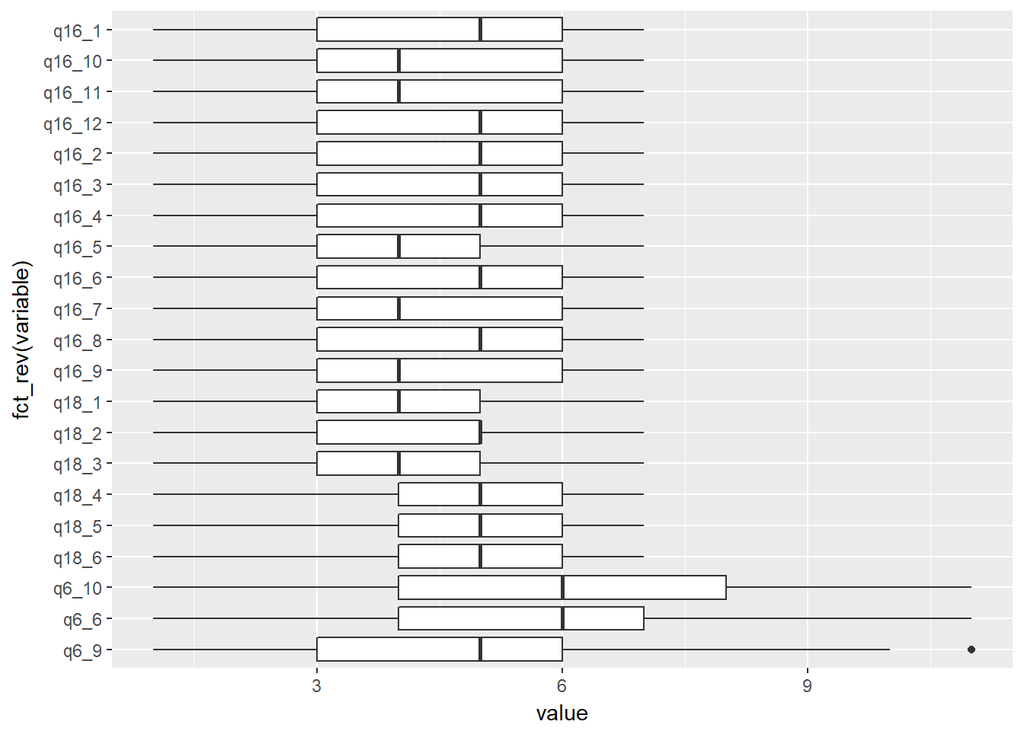

```r
attach(coll_df)
coll_df %>%
  gather(variable, value) %>%
  ggplot() +
  aes(x = fct_rev(variable), y = value) +
  geom_boxplot() +
  coord_flip()
```

```r
detach(coll_df)
```

Inquring into q6_9 with an outlier

An outlier was found in q6_9 which was prefered to be kept in the dataset.

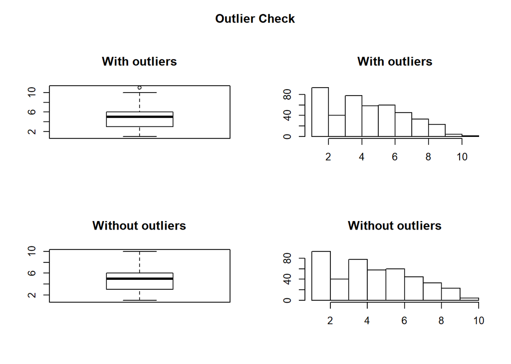

```
## Outliers identified: 1 nPropotion (%) of outliers: 0.2 nMean of the outliers: 11 nMean without removing outliers: 4.74 nMean if we remove outliers: 4.72 nDo you want to remove outliers and to replace with NA? [yes/no]:
## Nothing changed n
```

```r
outlierKD <- function(dt, var) {
     var_name <- eval(substitute(var),eval(dt))
     na1 <- sum(is.na(var_name))
     m1 <- mean(var_name, na.rm = T)
     par(mfrow=c(2, 2), oma=c(0,0,3,0))
     boxplot(var_name, main="With outliers")
     hist(var_name, main="With outliers", xlab=NA, ylab=NA)
     outlier <- boxplot.stats(var_name)$out
     mo <- mean(outlier)
     var_name <- ifelse(var_name %in% outlier, NA, var_name)
     boxplot(var_name, main="Without outliers")
     hist(var_name, main="Without outliers", xlab=NA, ylab=NA)
     title("Outlier Check", outer=TRUE)
     na2 <- sum(is.na(var_name))
     cat("Outliers identified:", na2 - na1, "n")
     cat("Propotion (%) of outliers:", round((na2 - na1) / sum(!is.na(var_name))*100, 1), "n")
     cat("Mean of the outliers:", round(mo, 2), "n")
     m2 <- mean(var_name, na.rm = T)
     cat("Mean without removing outliers:", round(m1, 2), "n")
     cat("Mean if we remove outliers:", round(m2, 2), "n")
     response <- readline(prompt="Do you want to remove outliers and to replace with NA? [yes/no]: ")
     if(response == "y" | response == "yes"){
          dt[as.character(substitute(var))] <- invisible(var_name)
          assign(as.character(as.list(match.call())$dt), dt, envir = .GlobalEnv)
          cat("Outliers successfully removed", "n")
          return(invisible(dt))
     } else{
          cat("Nothing changed", "n")
          return(invisible(var_name)) }}
outlierKD(coll_df, q6_9)
```

### Tests of Normality

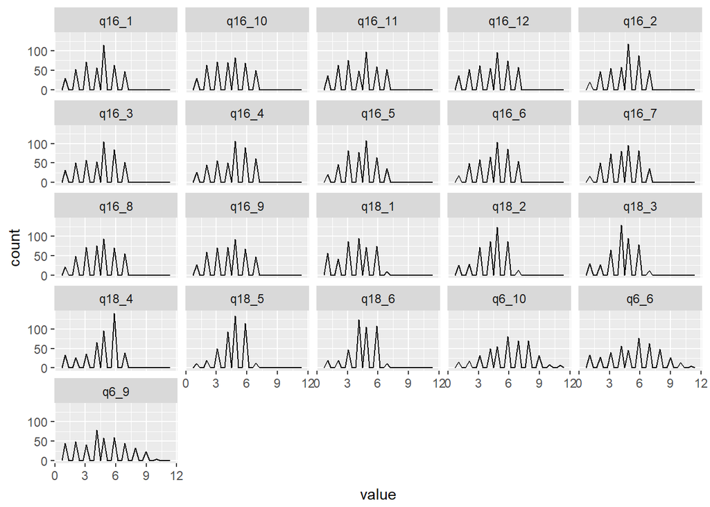

```r
coll_df %>%
  gather(variable, value) %>%
  ggplot() +
  aes(x = value) +
  geom_freqpoly() +
  facet_wrap(~variable)
```

### Correlation Analyses

#### Correlation Between Sets of Items Representing the Dependent Latent Variables Analysed in the SEM Models Later

Correlation between Items represnting Political Support and the Plot

q18_1. Muslims are allowed to politically organize themselves in the Netherlands in order to try to influence policy.

q18_4. Muslims are allowed to exercise important official duties (mayor, minister) in the Netherlands.

```r
cor(coll_df$q18_1 , coll_df$q18_4)
```

```
## [1] 0.6507516
```

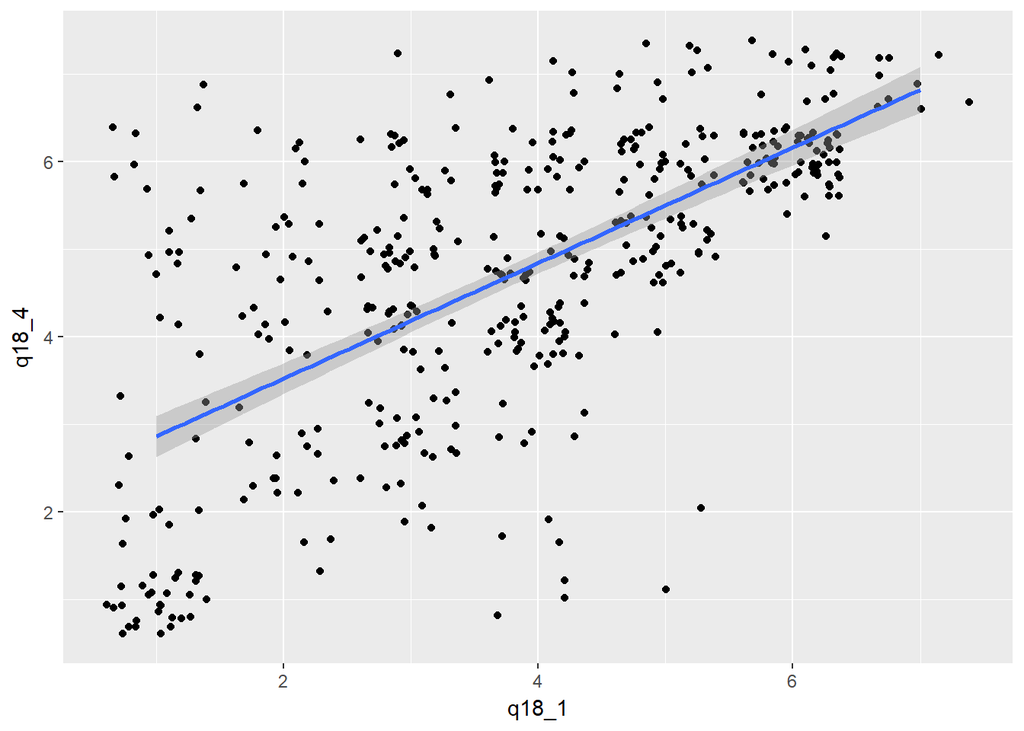

```r
ggplot(coll_df) +
  aes(x = q18_1 , y = q18_4) +
  geom_point(position = "jitter") +
  geom_smooth(method="lm")
```

Correlation between Items represnting Realistic Support and the Plot

q18_3. Muslims are allowed to maintain their cultural identity.

q18_6. Muslims are entitled to their own culture and traditions.

```r
cor(coll_df$q18_3 , coll_df$q18_6)
```

```
## [1] 0.7353277
```

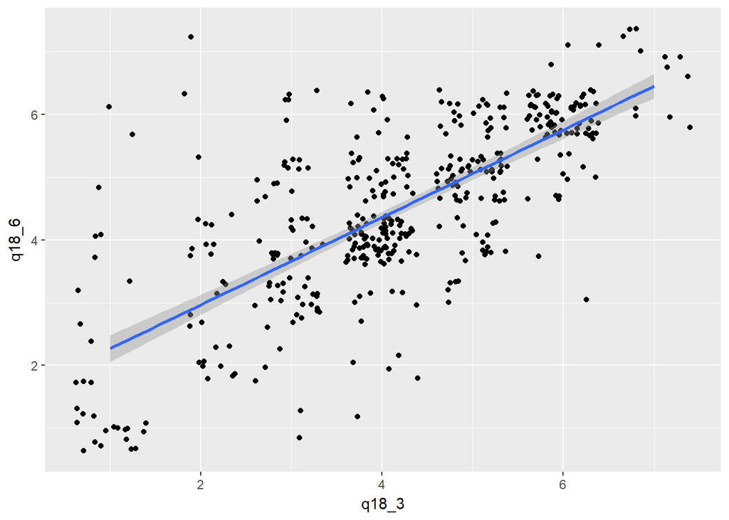

```r
ggplot(coll_df) +
  aes(x = q18_3 , y = q18_6) +
  geom_point(position = "jitter") +
  geom_smooth(method="lm")
```

Correlation between Items represnting Cultural Support and the Plot

q18_2. Much more attention is needed for discrimination of Muslims on the labour market.

q18_5. Better care should be taken of ensuring Muslims equal opportunities to get a good job.

```r
cor(coll_df$q18_2 , coll_df$q18_5)
```

```
## [1] 0.6639556
```

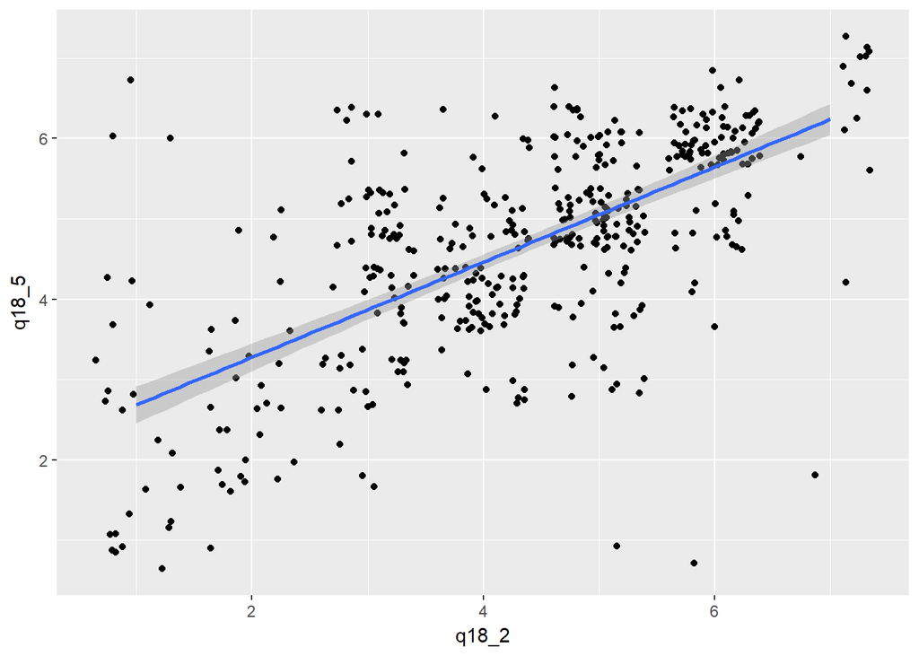

```r
ggplot(coll_df) +
  aes(x = q18_2 , y = q18_5) +
  geom_point(position = "jitter") +
  geom_smooth(method="lm")
```

#### Correlation between Three Froms of Threat (Symbolic, Realistic, and Collective Ownership) in a Path Analysis

For the independent variables, the correlation analyses were performed in factor level in a path analysis using a structural equation model.

```r
model <- ' st =~ q16_1 + q16_2 + q16_3 + q16_4
rt =~ q16_5 + q16_6 + q16_7 + q16_8
ct =~ q16_9 + q16_10 + q16_11 + q16_12
st ~~ rt
st ~~ ct
rt ~~ ct'
cormodel <- sem(model, data=coll_df)
summary(cormodel, fit.measures=TRUE, standardized=TRUE)
```

```
## lavaan (0.5-23.1097) converged normally after  46 iterations
##
##   Number of observations                           435
##
##   Estimator                                         ML
##   Minimum Function Test Statistic              134.035
##   Degrees of freedom                                51
##   P-value (Chi-square)                           0.000
##
## Model test baseline model:
##
##   Minimum Function Test Statistic             7152.763
##   Degrees of freedom                                66
##   P-value                                        0.000
##
## User model versus baseline model:
##
##   Comparative Fit Index (CFI)                    0.988
##   Tucker-Lewis Index (TLI)                       0.985
##
## Loglikelihood and Information Criteria:
##
##   Loglikelihood user model (H0)              -6752.163
##   Loglikelihood unrestricted model (H1)      -6685.145
##
##   Number of free parameters                         27
##   Akaike (AIC)                               13558.325
##   Bayesian (BIC)                             13668.360
##   Sample-size adjusted Bayesian (BIC)        13582.676
##
## Root Mean Square Error of Approximation:
##
##   RMSEA                                          0.061
##   90 Percent Confidence Interval          0.049  0.074
##   P-value RMSEA <= 0.05                          0.070
##
## Standardized Root Mean Square Residual:
##
##   SRMR                                           0.019
##
```

[output cut: 33 more lines]

```
##    .q16_1             0.357    0.031   11.480    0.000    0.357    0.120
##    .q16_2             0.435    0.035   12.357    0.000    0.435    0.156
##    .q16_3             0.327    0.030   10.854    0.000    0.327    0.103
##    .q16_4             0.447    0.037   12.115    0.000    0.447    0.144
##    .q16_5             0.696    0.056   12.323    0.000    0.696    0.270
##    .q16_6             0.845    0.067   12.627    0.000    0.845    0.297
##    .q16_7             0.576    0.050   11.569    0.000    0.576    0.221
##    .q16_8             0.522    0.049   10.622    0.000    0.522    0.180
##    .q16_9             0.285    0.026   10.892    0.000    0.285    0.094
##    .q16_10            0.319    0.029   11.180    0.000    0.319    0.101
##    .q16_11            0.519    0.041   12.578    0.000    0.519    0.154
##    .q16_12            0.430    0.036   12.002    0.000    0.430    0.127
##     st                2.631    0.202   13.017    0.000    1.000    1.000
##     rt                1.881    0.171   10.994    0.000    1.000    1.000
##     ct                2.745    0.205   13.370    0.000    1.000    1.000
```

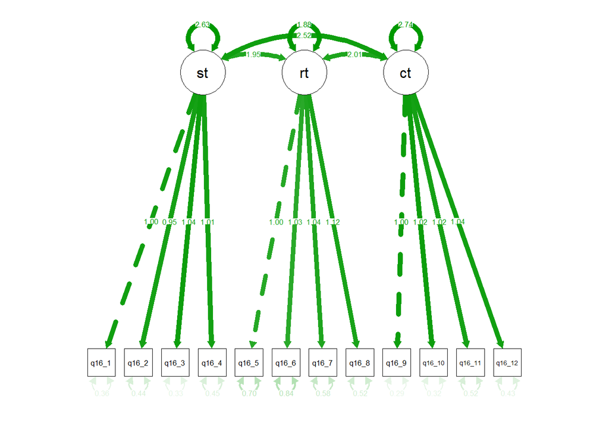

```r
semPaths(cormodel, "Standardized", "Estimates")
```

## Hypothesis I

I was hypothesized that there will be negative significant associations between the three forms of threat and support for the accommodation of migrants. The hypothesis was partly supported where higher degrees of symbolic and realistic threat resulted in lower support. Hwoever, there was no such a relatrionship between collective onwnership threat and support for the accommodation of migrants.

### Confirmatory Factor Analyses

Confirmatory factor analyses were computed for all latent variables (both independent and dependent). Regarding the dependent constructs, the model $x^{2}$ of 12.131 showed a marginal absolute fit (*p* = .0591), while other measures confirmed that the model fit is satisfactory: CFI = .995; TLI = .989; SRMR = .012; and RMSEA = .048 and 90% CI = .001 - .088. All the factor loadings were statistically significant (*p* < .001) and the standardized factor loadings were between .78 and .92. The model $x^{2}$ of 60.625 of the independent variables indicated a good model fit too (*p* = .1044) which was confirmed by other measures of model fit: CFI = .998; TLI = .998; SRMR = .01; and RMSEA = .02 and 90% CI = 0.001 - 0.042. All the factor loadings were statistically significant (*p* < .001) and the standardized factor loadings were between .83 and .95. Moreover, in order to improve the model fit, errors of two items from the symbolic threat scale and three items from the realistic threat scale were allowed to covary.

#### Conformatory Factor Analysis of the Dependent Variables

Model Specification

```r
modeldv <- ' pol =~ q18_1 + q18_4
real =~ q18_3 + q18_6
cul =~ q18_2 + q18_5'
fitdv <- cfa(modeldv, data=coll_df, std.lv=TRUE,missing="fiml")
```

Model Results and Plot

```r
summary(fitdv, fit.measures=TRUE, standardized=TRUE)
```

```
## lavaan (0.5-23.1097) converged normally after  23 iterations
##
##   Number of observations                           435
##
##   Number of missing patterns                         1
##
##   Estimator                                         ML
##   Minimum Function Test Statistic               12.131
##   Degrees of freedom                                 6
##   P-value (Chi-square)                           0.059
##
## Model test baseline model:
##
##   Minimum Function Test Statistic             1350.074
##   Degrees of freedom                                15
##   P-value                                        0.000
##
## User model versus baseline model:
##
##   Comparative Fit Index (CFI)                    0.995
##   Tucker-Lewis Index (TLI)                       0.989
##
## Loglikelihood and Information Criteria:
##
##   Loglikelihood user model (H0)              -4088.946
##   Loglikelihood unrestricted model (H1)      -4082.881
##
##   Number of free parameters                         21
##   Akaike (AIC)                                8219.892
##   Bayesian (BIC)                              8305.474
##   Sample-size adjusted Bayesian (BIC)         8238.831
##
## Root Mean Square Error of Approximation:
##
##   RMSEA                                          0.048
##   90 Percent Confidence Interval          0.000  0.088
##   P-value RMSEA <= 0.05                          0.467
##
## Standardized Root Mean Square Residual:
##
```

[output cut: 35 more lines]

```
##     pol               0.000                               0.000    0.000
##     real              0.000                               0.000    0.000
##     cul               0.000                               0.000    0.000
##
## Variances:
##                    Estimate  Std.Err  z-value  P(>|z|)   Std.lv  Std.all
##    .q18_1             1.004    0.108    9.283    0.000    1.004    0.365
##    .q18_4             0.940    0.111    8.475    0.000    0.940    0.333
##    .q18_3             0.799    0.078   10.235    0.000    0.799    0.368
##    .q18_6             0.281    0.071    3.955    0.000    0.281    0.144
##    .q18_2             0.614    0.084    7.333    0.000    0.614    0.278
##    .q18_5             0.684    0.067   10.147    0.000    0.684    0.389
##     pol               1.000                               1.000    1.000
##     real              1.000                               1.000    1.000
##     cul               1.000                               1.000    1.000
```

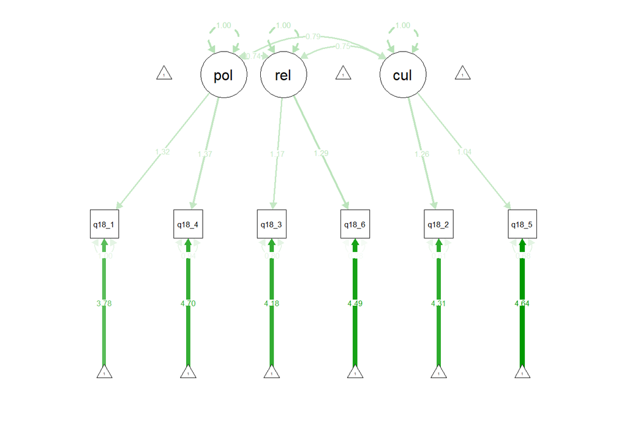

```r
semPaths(fitdv, "Standardized", "Estimates")
```

#### Conformatory Factor Analysis of the Independent Variables

Model Specification

```r
modeliv <- ' st =~ q16_1 + q16_2 + q16_3 + q16_4
rt =~ q16_5 + q16_6 + q16_7 + q16_8
co =~ q16_9 + q16_10 + q16_11 + q16_12'

fitiv <- cfa(modeliv, data=coll_df, std.lv=TRUE,missing="fiml")
```

Model Results

```r
summary(fitiv, fit.measures=TRUE, standardized=TRUE)
```

```
## lavaan (0.5-23.1097) converged normally after  41 iterations
##
##   Number of observations                           435
##
##   Number of missing patterns                         1
##
##   Estimator                                         ML
##   Minimum Function Test Statistic              134.035
##   Degrees of freedom                                51
##   P-value (Chi-square)                           0.000
##
## Model test baseline model:
##
##   Minimum Function Test Statistic             7152.763
##   Degrees of freedom                                66
##   P-value                                        0.000
##
## User model versus baseline model:
##
##   Comparative Fit Index (CFI)                    0.988
##   Tucker-Lewis Index (TLI)                       0.985
##
## Loglikelihood and Information Criteria:
##
##   Loglikelihood user model (H0)              -6752.163
##   Loglikelihood unrestricted model (H1)      -6685.145
##
##   Number of free parameters                         39
##   Akaike (AIC)                               13582.325
##   Bayesian (BIC)                             13741.264
##   Sample-size adjusted Bayesian (BIC)        13617.499
##
## Root Mean Square Error of Approximation:
##
##   RMSEA                                          0.061
##   90 Percent Confidence Interval          0.049  0.074
##   P-value RMSEA <= 0.05                          0.070
##
## Standardized Root Mean Square Residual:
##
```

[output cut: 53 more lines]

```
##    .q16_1             0.357    0.031   11.371    0.000    0.357    0.120
##    .q16_2             0.435    0.035   12.338    0.000    0.435    0.156
##    .q16_3             0.327    0.030   10.782    0.000    0.327    0.103
##    .q16_4             0.447    0.037   12.067    0.000    0.447    0.144
##    .q16_5             0.696    0.059   11.847    0.000    0.696    0.270
##    .q16_6             0.845    0.067   12.619    0.000    0.845    0.297
##    .q16_7             0.576    0.052   11.139    0.000    0.576    0.221
##    .q16_8             0.522    0.051   10.227    0.000    0.522    0.180
##    .q16_9             0.285    0.026   10.855    0.000    0.285    0.094
##    .q16_10            0.319    0.029   11.162    0.000    0.319    0.101
##    .q16_11            0.519    0.041   12.554    0.000    0.519    0.154
##    .q16_12            0.430    0.036   11.969    0.000    0.430    0.127
##     st                1.000                               1.000    1.000
##     rt                1.000                               1.000    1.000
##     co                1.000                               1.000    1.000
```

Model Modification

```r
modificationIndices(fitiv, sort.=TRUE, minimum.value=3)
```

```
##       lhs op    rhs     mi    epc sepc.lv sepc.all sepc.nox
## 109 q16_5 ~~  q16_7 54.930  0.306   0.306    0.118    0.118
## 49     st =~  q16_8 39.267  0.748   0.748    0.439    0.439
## 110 q16_5 ~~  q16_8 31.579 -0.239  -0.239   -0.088   -0.088
## 69     co =~  q16_8 31.308  0.707   0.707    0.415    0.415
## 48     st =~  q16_7 12.362 -0.404  -0.404   -0.251   -0.251
## 68     co =~  q16_7 12.112 -0.422  -0.422   -0.262   -0.262
## 72  q16_1 ~~  q16_4 10.304  0.086   0.086    0.028    0.028
## 127 q16_8 ~~ q16_10  7.318  0.070   0.070    0.023    0.023
## 71  q16_1 ~~  q16_3  7.228 -0.069  -0.069   -0.022   -0.022
## 52     st =~ q16_11  5.868 -0.352  -0.352   -0.192   -0.192
## 84  q16_2 ~~  q16_6  4.823  0.075   0.075    0.026    0.026
## 121 q16_7 ~~  q16_8  4.793 -0.092  -0.092   -0.034   -0.034
## 106 q16_4 ~~ q16_11  4.517 -0.058  -0.058   -0.018   -0.018
## 65     co =~  q16_4  4.321 -0.294  -0.294   -0.167   -0.167
## 46     st =~  q16_5  4.298 -0.245  -0.245   -0.153   -0.153
## 81  q16_2 ~~  q16_3  4.207  0.053   0.053    0.018    0.018
## 57     rt =~  q16_4  4.043 -0.187  -0.187   -0.106   -0.106
## 79  q16_1 ~~ q16_11  3.986 -0.050  -0.050   -0.016   -0.016
## 74  q16_1 ~~  q16_6  3.546 -0.060  -0.060   -0.021   -0.021
## 66     co =~  q16_5  3.541 -0.234  -0.234   -0.146   -0.146
## 131 q16_9 ~~ q16_11  3.537  0.049   0.049    0.015    0.015
## 125 q16_7 ~~ q16_12  3.219 -0.053  -0.053   -0.018   -0.018
## 61     rt =~ q16_12  3.031 -0.167  -0.167   -0.091   -0.091
```

Modified Model

```r
modeliv <- 'sT =~ q16_1 + q16_2 + q16_3 + q16_4
rT =~ q16_5 + q16_6 + q16_7 + q16_8
cO =~ q16_9 + q16_10 + q16_11 + q16_12
q16_4 ~~ q16_1
q16_7 ~~ q16_5
q16_8 ~~ q16_5'
fitiv <- cfa(modeliv, data=coll_df, std.lv=TRUE,missing="fiml")
```

Model Results and Plot

```r
summary(fitiv, fit.measures=TRUE, standardized=TRUE)
```

```
## lavaan (0.5-23.1097) converged normally after  41 iterations
##
##   Number of observations                           435
##
##   Number of missing patterns                         1
##
##   Estimator                                         ML
##   Minimum Function Test Statistic               60.625
##   Degrees of freedom                                48
##   P-value (Chi-square)                           0.104
##
## Model test baseline model:
##
##   Minimum Function Test Statistic             7152.763
##   Degrees of freedom                                66
##   P-value                                        0.000
##
## User model versus baseline model:
##
##   Comparative Fit Index (CFI)                    0.998
##   Tucker-Lewis Index (TLI)                       0.998
##
## Loglikelihood and Information Criteria:
##
##   Loglikelihood user model (H0)              -6715.457
##   Loglikelihood unrestricted model (H1)      -6685.145
##
##   Number of free parameters                         42
##   Akaike (AIC)                               13514.915
##   Bayesian (BIC)                             13686.079
##   Sample-size adjusted Bayesian (BIC)        13552.794
##
## Root Mean Square Error of Approximation:
##
##   RMSEA                                          0.025
##   90 Percent Confidence Interval          0.000  0.042
##   P-value RMSEA <= 0.05                          0.995
##
## Standardized Root Mean Square Residual:
##
```

[output cut: 58 more lines]

```
##    .q16_1             0.396    0.036   11.150    0.000    0.396    0.133
##    .q16_2             0.423    0.035   12.052    0.000    0.423    0.151
##    .q16_3             0.309    0.030   10.138    0.000    0.309    0.097
##    .q16_4             0.492    0.042   11.759    0.000    0.492    0.158
##    .q16_5             0.747    0.072   10.391    0.000    0.747    0.290
##    .q16_6             0.861    0.068   12.692    0.000    0.861    0.303
##    .q16_7             0.718    0.060   11.985    0.000    0.718    0.276
##    .q16_8             0.389    0.048    8.164    0.000    0.389    0.134
##    .q16_9             0.286    0.026   10.866    0.000    0.286    0.094
##    .q16_10            0.319    0.029   11.154    0.000    0.319    0.101
##    .q16_11            0.518    0.041   12.553    0.000    0.518    0.154
##    .q16_12            0.430    0.036   11.974    0.000    0.430    0.127
##     sT                1.000                               1.000    1.000
##     rT                1.000                               1.000    1.000
##     cO                1.000                               1.000    1.000
```

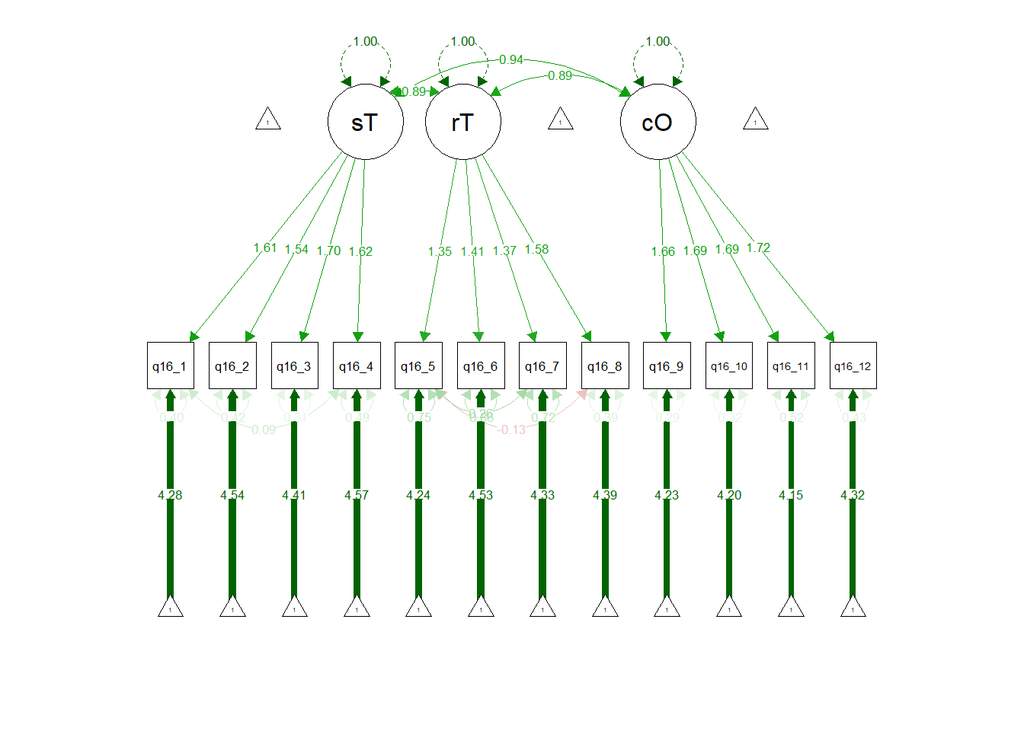

```r
semPaths(fitiv, "Standardized", "Estimates")
```

### Structural Model

The structural model indicated a good model fit ($x^{2} = 139.358$ ; df = 117; CFI = .997; TLI = .997; RMSEA = .021 with 90% CI = .001- .033). Hence, the model fit manifests that the model is apt to explaining the association among the constructs. The path coefficients from symbolic threat to political ($\beta$ = -.36, *p* = .023), cultural ($\beta$ = -.385, *p* = .031), and real support ($\beta$ = -.438, *p* = .009) were significantly negative. The path coefficients from realistic threat to political ($\beta$ = -.259, *p* = .02), cultural ($\beta$ = -0.28, *p* = .02), and real support ($\beta$ = -.327, *p* = 0.005) were also significantly negative. Path coefficient of collective ownership threat to the three forms of support, however, were not found significant. Hence, the higher perception of realistic and symbolic types of threat the lesser tendency on the support for integration of Muslims in the Netherlands.

```r
model <- 'pol =~ q18_1 + q18_4
real =~ q18_3 + q18_6
cul =~ q18_2 + q18_5
st =~ q16_1 + q16_2 + q16_3 + q16_4
rt =~ q16_5 + q16_6 + q16_7 + q16_8
co =~ q16_9 + q16_10 + q16_11 + q16_12
pol ~ st + rt + co
real ~ st + rt + co
cul ~ st + rt + co
pol ~~ real
pol ~~ cul
real ~~ cul'
fitsem <- cfa(model, data=coll_df, std.lv=TRUE,missing="fiml")
summary(fitsem, fit.measures=TRUE)
```

```
## lavaan (0.5-23.1097) converged normally after  69 iterations
##
##   Number of observations                           435
##
##   Number of missing patterns                         1
##
##   Estimator                                         ML
##   Minimum Function Test Statistic              214.550
##   Degrees of freedom                               120
##   P-value (Chi-square)                           0.000
##
## Model test baseline model:
##
##   Minimum Function Test Statistic             8854.429
##   Degrees of freedom                               153
##   P-value                                        0.000
##
## User model versus baseline model:
##
##   Comparative Fit Index (CFI)                    0.989
##   Tucker-Lewis Index (TLI)                       0.986
##
## Loglikelihood and Information Criteria:
##
##   Loglikelihood user model (H0)             -10699.505
##   Loglikelihood unrestricted model (H1)     -10592.230
##
##   Number of free parameters                         69
##   Akaike (AIC)                               21537.010
##   Bayesian (BIC)                             21818.209
##   Sample-size adjusted Bayesian (BIC)        21599.240
##
## Root Mean Square Error of Approximation:
##
##   RMSEA                                          0.043
##   90 Percent Confidence Interval          0.033  0.052
##   P-value RMSEA <= 0.05                          0.908
##
## Standardized Root Mean Square Residual:
##
```

[output cut: 100 more lines]

```
##    .q16_4             0.448    0.037   12.100    0.000
##    .q16_5             0.698    0.059   11.867    0.000
##    .q16_6             0.849    0.067   12.655    0.000
##    .q16_7             0.580    0.052   11.193    0.000
##    .q16_8             0.515    0.051   10.177    0.000
##    .q16_9             0.288    0.026   10.891    0.000
##    .q16_10            0.321    0.029   11.194    0.000
##    .q16_11            0.516    0.041   12.542    0.000
##    .q16_12            0.426    0.036   11.927    0.000
##    .pol               1.000
##    .real              1.000
##    .cul               1.000
##     st                1.000
##     rt                1.000
##     co                1.000
```

Mdel Modification

```r
modificationIndices(fitsem, sort.=TRUE, minimum.value=3)
```

```
##       lhs op    rhs     mi    epc sepc.lv sepc.all sepc.nox
## 298 q16_5 ~~  q16_7 55.484  0.307   0.307    0.118    0.118
## 139    st =~  q16_8 38.126  0.737   0.737    0.432    0.432
## 299 q16_5 ~~  q16_8 33.106 -0.243  -0.243   -0.089   -0.089
## 171    co =~  q16_8 28.739  0.675   0.675    0.396    0.396
## 138    st =~  q16_7 12.022 -0.399  -0.399   -0.248   -0.248
## 170    co =~  q16_7 11.329 -0.408  -0.408   -0.253   -0.253
## 109  real =~  q16_8 10.499 -0.152  -0.191   -0.112   -0.112
## 261 q16_1 ~~  q16_4 10.123  0.085   0.085    0.028    0.028
## 125   cul =~  q16_8  9.710 -0.152  -0.189   -0.111   -0.111
## 190 q18_4 ~~  q18_6  8.680  0.151   0.151    0.064    0.064
## 189 q18_4 ~~  q18_3  8.368 -0.158  -0.158   -0.064   -0.064
## 93    pol =~  q16_8  8.345 -0.146  -0.221   -0.130   -0.130
## 97    pol =~ q16_12  8.124 -0.117  -0.177   -0.096   -0.096
## 316 q16_8 ~~ q16_10  7.719  0.072   0.072    0.024    0.024
```

[output cut: 32 more lines]

Modified Model Fit of the Structural Model

```r
model<- 'pol =~ q18_1 + q18_4
real =~ q18_3 + q18_6
cul =~ q18_2 + q18_5
st =~ q16_1 + q16_2 + q16_3 + q16_4
rt =~ q16_5 + q16_6 + q16_7 + q16_8
co =~ q16_9 + q16_10 + q16_11 + q16_12
pol ~ st + rt + co
real ~ st + rt + co
cul ~ st + rt + co
q16_7 ~~ q16_5
q16_8 ~~ q16_5
q16_4 ~~ q16_1
pol ~~ real
pol ~~ cul
real ~~ cul'
fitsem <- cfa(model, data=coll_df, std.lv=TRUE,missing="fiml")
summary(fitsem, fit.measures=TRUE)
```

```
## lavaan (0.5-23.1097) converged normally after  73 iterations
##
##   Number of observations                           435
##
##   Number of missing patterns                         1
##
##   Estimator                                         ML
##   Minimum Function Test Statistic              139.358
##   Degrees of freedom                               117
##   P-value (Chi-square)                           0.078
##
## Model test baseline model:
##
##   Minimum Function Test Statistic             8854.429
##   Degrees of freedom                               153
##   P-value                                        0.000
##
## User model versus baseline model:
##
##   Comparative Fit Index (CFI)                    0.997
##   Tucker-Lewis Index (TLI)                       0.997
##
## Loglikelihood and Information Criteria:
##
##   Loglikelihood user model (H0)             -10661.909
##   Loglikelihood unrestricted model (H1)     -10592.230
##
##   Number of free parameters                         72
##   Akaike (AIC)                               21467.818
##   Bayesian (BIC)                             21761.243
##   Sample-size adjusted Bayesian (BIC)        21532.753
##
## Root Mean Square Error of Approximation:
##
##   RMSEA                                          0.021
##   90 Percent Confidence Interval          0.000  0.033
##   P-value RMSEA <= 0.05                          1.000
##
## Standardized Root Mean Square Residual:
##
```

[output cut: 105 more lines]

```
##    .q16_4             0.492    0.042   11.789    0.000
##    .q16_5             0.744    0.072   10.397    0.000
##    .q16_6             0.869    0.068   12.766    0.000
##    .q16_7             0.722    0.060   12.041    0.000
##    .q16_8             0.380    0.047    8.099    0.000
##    .q16_9             0.288    0.026   10.902    0.000
##    .q16_10            0.321    0.029   11.187    0.000
##    .q16_11            0.516    0.041   12.540    0.000
##    .q16_12            0.427    0.036   11.932    0.000
##    .pol               1.000
##    .real              1.000
##    .cul               1.000
##     st                1.000
##     rt                1.000
##     co                1.000
```

Modified Strucrural Model results and Plot

```r
model<- 'pol =~ q18_1 + q18_4
real =~ q18_3 + q18_6
cul =~ q18_2 + q18_5
st =~ q16_1 + q16_2 + q16_3 + q16_4
rt =~ q16_5 + q16_6 + q16_7 + q16_8
co =~ q16_9 + q16_10 + q16_11 + q16_12
pol ~ st + rt + co
real ~ st + rt + co
cul ~ st + rt + co
q16_7 ~~ q16_5
q16_8 ~~ q16_5
q16_4 ~~ q16_1
pol ~~ real
pol ~~ cul
real ~~ cul'
smodel <- sem(model, data=coll_df)
summary(smodel, standardized=TRUE)
```

```
## lavaan (0.5-23.1097) converged normally after  73 iterations
##
##   Number of observations                           435
##
##   Estimator                                         ML
##   Minimum Function Test Statistic              139.358
##   Degrees of freedom                               117
##   P-value (Chi-square)                           0.078
##
## Parameter Estimates:
##
##   Information                                 Expected
##   Standard Errors                             Standard
##
## Latent Variables:
##                    Estimate  Std.Err  z-value  P(>|z|)   Std.lv  Std.all
##   pol =~
##     q18_1             1.000                               1.290    0.778
##     q18_4             1.089    0.064   17.020    0.000    1.406    0.836
##   real =~
##     q18_3             1.000                               1.187    0.806
##     q18_6             1.074    0.058   18.459    0.000    1.275    0.913
##   cul =~
##     q18_2             1.000                               1.262    0.849
##     q18_5             0.821    0.051   16.209    0.000    1.036    0.782
##   st =~
##     q16_1             1.000                               1.611    0.932
##     q16_2             0.956    0.027   35.326    0.000    1.540    0.921
##     q16_3             1.053    0.027   39.555    0.000    1.696    0.950
##     q16_4             1.005    0.026   38.938    0.000    1.618    0.918
##   rt =~
##     q16_5             1.000                               1.352    0.843
##     q16_6             1.040    0.049   21.152    0.000    1.407    0.834
##     q16_7             1.014    0.037   27.280    0.000    1.371    0.850
##     q16_8             1.174    0.050   23.459    0.000    1.588    0.932
##   co =~
##     q16_9             1.000                               1.656    0.951
##     q16_10            1.018    0.023   43.595    0.000    1.686    0.948
##     q16_11            1.018    0.027   38.164    0.000    1.686    0.920
##     q16_12            1.040    0.025   40.891    0.000    1.723    0.935
```

[output cut: 45 more lines]

```
##    .q16_4             0.492    0.042   11.790    0.000    0.492    0.158
##    .q16_5             0.744    0.070   10.592    0.000    0.744    0.289
##    .q16_6             0.869    0.068   12.783    0.000    0.869    0.305
##    .q16_7             0.722    0.059   12.151    0.000    0.722    0.278
##    .q16_8             0.380    0.047    8.081    0.000    0.380    0.131
##    .q16_9             0.288    0.026   10.946    0.000    0.288    0.095
##    .q16_10            0.321    0.029   11.209    0.000    0.321    0.101
##    .q16_11            0.516    0.041   12.571    0.000    0.516    0.154
##    .q16_12            0.427    0.036   11.984    0.000    0.427    0.126
##    .pol               0.732    0.098    7.487    0.000    0.439    0.439
##    .real              0.884    0.097    9.153    0.000    0.628    0.628
##    .cul               1.023    0.116    8.820    0.000    0.643    0.643
##     st                2.594    0.202   12.834    0.000    1.000    1.000
##     rt                1.829    0.174   10.534    0.000    1.000    1.000
##     co                2.742    0.205   13.357    0.000    1.000    1.000
```

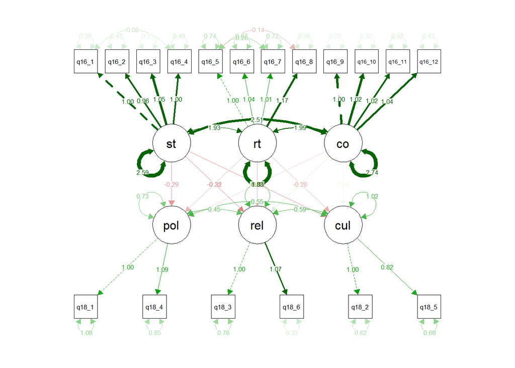

```r
semPaths(smodel, "Standardized", "Estimates")
```

## Hypothesis II

I was hypothesized that higher perception of threat would lead to higher perception of negative feelings. The hypothesis was again partially supported as only symbolic threat significantly was associated with higher negative feelings. While no significant relations was found between the other two forms of threat, realistic and collective ownership, and perception of negative feelings.

### Structural Model

A structural equation modeling was conducted to measure the effect of three forms of threat on thermometer questions. The chi-square test didn’t show an absolute fit ($x^{2} = 185.963$; df = 84; *p* < .001). However, other measures indicated a satisfactory model fit in general; CFI = .987; TLI = .984; SRMR = .023; and RMSEA = .053 and 90% CI < 0.043 - .063. The results showed that the path coefficients from symbolic threat to thermometer questions ($\beta$ = -.446, *p* = .003) were found to be significant. In other words, the higher the symbolic threat the more negative feelings are perceived. No significant statistics were found from the path coefficients of collective ownership and realistic types of threat on the thermometer questions.

Model Fit

```r
model<- 'thermo =~ q6_6 + q6_9 + q6_10
st =~ q16_1 + q16_2 + q16_3 + q16_4
rt =~ q16_5 + q16_6 + q16_7 + q16_8
co =~ q16_9 + q16_10 + q16_11 + q16_12
thermo ~ st + rt + co'
fitsem <- cfa(model, data=coll_df, std.lv=TRUE,missing="fiml")
summary(fitsem, fit.measures=TRUE)
```

```
## lavaan (0.5-23.1097) converged normally after  48 iterations
##
##   Number of observations                           435
##
##   Number of missing patterns                         1
##
##   Estimator                                         ML
##   Minimum Function Test Statistic              185.963
##   Degrees of freedom                                84
##   P-value (Chi-square)                           0.000
##
## Model test baseline model:
##
##   Minimum Function Test Statistic             8186.651
##   Degrees of freedom                               105
##   P-value                                        0.000
##
## User model versus baseline model:
##
##   Comparative Fit Index (CFI)                    0.987
##   Tucker-Lewis Index (TLI)                       0.984
##
## Loglikelihood and Information Criteria:
##
##   Loglikelihood user model (H0)              -9222.546
##   Loglikelihood unrestricted model (H1)      -9129.564
##
##   Number of free parameters                         51
##   Akaike (AIC)                               18547.092
##   Bayesian (BIC)                             18754.934
##   Sample-size adjusted Bayesian (BIC)        18593.087
##
## Root Mean Square Error of Approximation:
##
##   RMSEA                                          0.053
##   90 Percent Confidence Interval          0.043  0.063
##   P-value RMSEA <= 0.05                          0.312
##
## Standardized Root Mean Square Residual:
##
```

[output cut: 72 more lines]

```
##    .q16_2             0.436    0.035   12.365    0.000
##    .q16_3             0.329    0.030   10.847    0.000
##    .q16_4             0.443    0.037   12.063    0.000
##    .q16_5             0.701    0.059   11.854    0.000
##    .q16_6             0.847    0.067   12.630    0.000
##    .q16_7             0.577    0.052   11.145    0.000
##    .q16_8             0.517    0.051   10.162    0.000
##    .q16_9             0.287    0.026   10.877    0.000
##    .q16_10            0.318    0.029   11.153    0.000
##    .q16_11            0.519    0.041   12.556    0.000
##    .q16_12            0.430    0.036   11.971    0.000
##    .thermo            1.000
##     st                1.000
##     rt                1.000
##     co                1.000
```

Model Specification,Results, and Plot

```r
model<- 'thermo =~ q6_6 + q6_9 + q6_10
st =~ q16_1 + q16_2 + q16_3 + q16_4
rt =~ q16_5 + q16_6 + q16_7 + q16_8
co =~ q16_9 + q16_10 + q16_11 + q16_12
thermo ~ st + rt + co'
Thermomodel <- sem(model, data=coll_df)
summary(Thermomodel, standardized=TRUE)
```

```
## lavaan (0.5-23.1097) converged normally after  66 iterations
##
##   Number of observations                           435
##
##   Estimator                                         ML
##   Minimum Function Test Statistic              185.963
##   Degrees of freedom                                84
##   P-value (Chi-square)                           0.000
##
## Parameter Estimates:
##
##   Information                                 Expected
##   Standard Errors                             Standard
##
## Latent Variables:
##                    Estimate  Std.Err  z-value  P(>|z|)   Std.lv  Std.all
##   thermo =~
##     q6_6              1.000                               2.248    0.915
##     q6_9              0.906    0.037   24.174    0.000    2.038    0.869
##     q6_10             0.773    0.038   20.480    0.000    1.738    0.781
##   st =~
##     q16_1             1.000                               1.622    0.938
##     q16_2             0.947    0.026   36.012    0.000    1.536    0.919
##     q16_3             1.043    0.026   40.556    0.000    1.691    0.947
##     q16_4             1.007    0.027   37.078    0.000    1.633    0.926
##   rt =~
##     q16_5             1.000                               1.370    0.853
##     q16_6             1.032    0.046   22.441    0.000    1.414    0.838
##     q16_7             1.039    0.042   24.591    0.000    1.423    0.882
##     q16_8             1.127    0.044   25.867    0.000    1.544    0.906
##   co =~
##     q16_9             1.000                               1.656    0.952
##     q16_10            1.019    0.023   43.744    0.000    1.687    0.948
##     q16_11            1.018    0.027   38.132    0.000    1.685    0.920
##     q16_12            1.040    0.025   40.843    0.000    1.722    0.935
##
## Regressions:
##                    Estimate  Std.Err  z-value  P(>|z|)   Std.lv  Std.all
##   thermo ~
##     st               -0.619    0.209   -2.967    0.003   -0.446   -0.446
```

[output cut: 17 more lines]

```
##    .q16_2             0.436    0.035   12.385    0.000    0.436    0.156
##    .q16_3             0.329    0.030   10.915    0.000    0.329    0.103
##    .q16_4             0.443    0.037   12.114    0.000    0.443    0.142
##    .q16_5             0.701    0.057   12.351    0.000    0.701    0.272
##    .q16_6             0.847    0.067   12.641    0.000    0.847    0.297
##    .q16_7             0.577    0.050   11.588    0.000    0.577    0.222
##    .q16_8             0.517    0.049   10.584    0.000    0.517    0.178
##    .q16_9             0.287    0.026   10.919    0.000    0.287    0.095
##    .q16_10            0.318    0.028   11.173    0.000    0.318    0.101
##    .q16_11            0.519    0.041   12.581    0.000    0.519    0.154
##    .q16_12            0.430    0.036   12.003    0.000    0.430    0.127
##    .thermo            2.922    0.264   11.054    0.000    0.578    0.578
##     st                2.630    0.202   13.016    0.000    1.000    1.000
##     rt                1.877    0.171   10.975    0.000    1.000    1.000
##     co                2.743    0.205   13.363    0.000    1.000    1.000
```

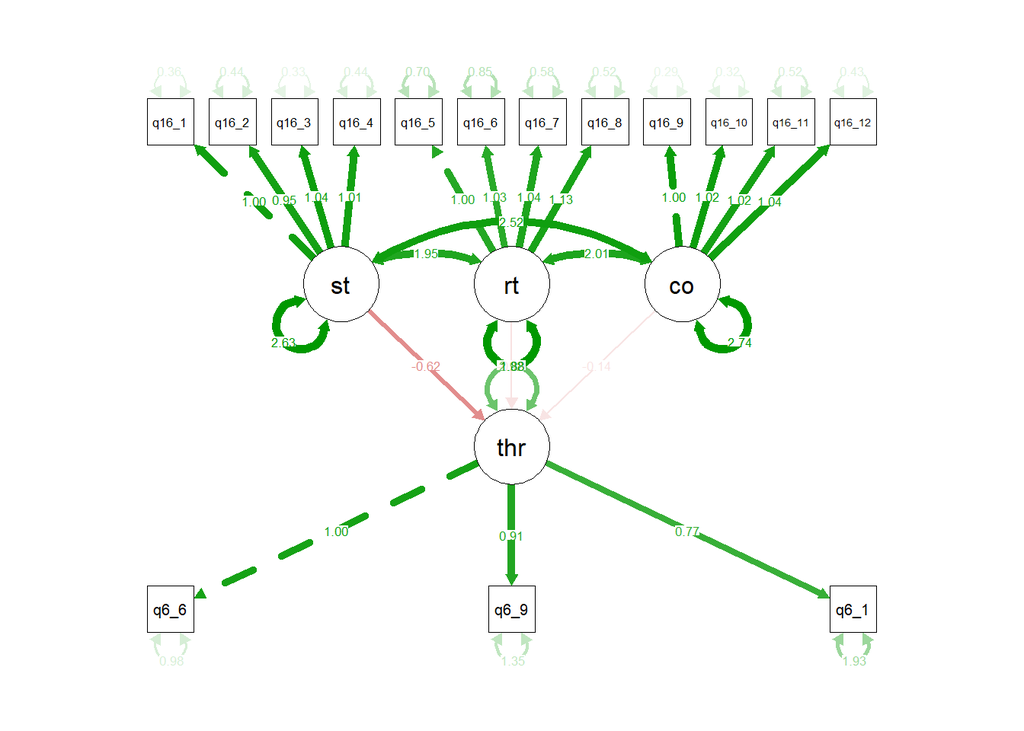

```r
semPaths(Thermomodel, "Standardized", "Estimates")
```

## Conclusion

Results obtained from two structural equation models showed that perception of threat would lead members of the host society not to support accommodation of migrants. More specifically, the results of the current study suggests that having been exposed to symbolic threat would be a stronger predictor of lack of support for accommodation of migrants compared to the other two types of threat; collective ownership and realistic. Further, it is important to consider the role of emotions with regard to perception of threat. As the results suggested, exposure to threat would cause perception of negative feelings.